# Interactions and scaling of regression inputs

Author

Maciej Beręsewicz

## 1 Introduction

This supplementary notebook covers categorical $\times$ continuous interactions, centering, standardisation, and Gelman’s (2008) approach to scaling regression inputs. These techniques improve coefficient interpretability, especially in models with interactions.

**References:**

- Gelman, A. (2008). Scaling regression inputs by dividing by two standard deviations. *Statistics in Medicine*, 27(15), 2865–2873. [PDF](https://sites.stat.columbia.edu/gelman/research/published/standardizing7.pdf)

## 2 Data

**R**

```r
library(ggplot2)
df <- read.csv("data/polish-jvs.csv", colClasses = c("character", "factor", rep("character", 4), "numeric"))
nace_counts <- as.data.frame(table(df$nace_division))
names(nace_counts) <- c("nace_division", "n_firms")
df <- merge(df, nace_counts, by = "nace_division")
df$n_firms <- as.numeric(df$n_firms) / 1000  ## in thousands for readable coefficients
head(df[, c("nace_division", "size", "n_firms", "vacancies")])
```

| nace_division | size | n_firms | vacancies |
| --- | --- | --- | --- |
| 01 | Small | 0.923 | 4 |
| 01 | Small | 0.923 | 0 |
| 01 | Small | 0.923 | 0 |
| 01 | Small | 0.923 | 0 |
| 01 | Medium | 0.923 | 0 |
| 01 | Small | 0.923 | 0 |

**Python**

```python
import pandas as pd
import numpy as np
import statsmodels.formula.api as smf
import matplotlib.pyplot as plt

df = pd.read_csv("data/polish-jvs.csv", dtype={"id": np.int64, "woj":str, "public":str,"size": str, "nace_division": str, "nace": str})
nace_counts = df.groupby("nace_division").size().reset_index(name="n_firms")
df = df.merge(nace_counts, on="nace_division")
df["n_firms"] = df["n_firms"] / 1000  ## in thousands for readable coefficients
print(df[["nace_division", "size", "n_firms", "vacancies"]].head())
```

```
  nace_division    size  n_firms  vacancies
0            84   Large    3.338          2
1            84   Large    3.338          1
2            84   Large    3.338          2
3            84  Medium    3.338          0
4            84  Medium    3.338          0
```

**Julia**

```julia
using CSV, DataFrames, GLM, Statistics

df = CSV.read("data/polish-jvs.csv", DataFrame,
              types = Dict(:id => String, :woj=> String, :public=> String,
                           :size => String, :nace_division => String, :nace => String))
```

```
57480×7 DataFrame
   Row │ id      woj     public  size    nace    nace_division  vacancies
       │ String  String  String  String  String  String         Int64
───────┼──────────────────────────────────────────────────────────────────
     1 │ 27350   14      1       Large   O       84                     2
     2 │ 26705   14      1       Large   O       84                     1
     3 │ 257456  24      1       Large   O       84                     2
     4 │ 183657  16      1       Medium  O       84                     0
     5 │ 200042  18      1       Medium  O       84                     0
     6 │ 26050   14      1       Large   R       91                     4
     7 │ 27351   14      1       Large   R       91                     2
     8 │ 26707   14      1       Large   R       91                     0
   ⋮   │   ⋮       ⋮       ⋮       ⋮       ⋮           ⋮            ⋮
 57474 │ 12042   08      1       Medium  R       91                     0
 57475 │ 203343  08      0       Small   A       01                     0
 57476 │ 244800  08      1       Medium  P       85                     0
 57477 │ 62309   08      1       Medium  R       93                     0
 57478 │ 106708  08      0       Medium  B       08                     0
 57479 │ 62264   08      0       Medium  B       08                     0
 57480 │ 255865  08      0       Small   C       23                     0
                                                        57465 rows omitted
```

```julia
nace_counts = combine(groupby(df, :nace_division), nrow => :n_firms)
```

```
84×2 DataFrame
 Row │ nace_division  n_firms
     │ String         Int64
─────┼────────────────────────
   1 │ 84                3338
   2 │ 91                1132
   3 │ 85               10071
   4 │ 62                1039
   5 │ 01                 923
   6 │ 72                 272
   7 │ 02                 867
   8 │ 64                1459
  ⋮  │       ⋮           ⋮
  78 │ 75                  39
  79 │ 06                   9
  80 │ 39                  68
  81 │ 51                   8
  82 │ 09                  91
  83 │ 53                  26
  84 │ 07                  11
               69 rows omitted
```

```julia
df = leftjoin(df, nace_counts, on = :nace_division)
```

```
57480×8 DataFrame
   Row │ id      woj     public  size    nace    nace_division  vacancies  n_f ⋯
       │ String  String  String  String  String  String         Int64      Int ⋯
───────┼────────────────────────────────────────────────────────────────────────
     1 │ 27350   14      1       Large   O       84                     2      ⋯
     2 │ 26705   14      1       Large   O       84                     1
     3 │ 257456  24      1       Large   O       84                     2
     4 │ 183657  16      1       Medium  O       84                     0
     5 │ 200042  18      1       Medium  O       84                     0      ⋯
     6 │ 26050   14      1       Large   R       91                     4
     7 │ 27351   14      1       Large   R       91                     2
     8 │ 26707   14      1       Large   R       91                     0
   ⋮   │   ⋮       ⋮       ⋮       ⋮       ⋮           ⋮            ⋮          ⋱
 57474 │ 12042   08      1       Medium  R       91                     0      ⋯
 57475 │ 203343  08      0       Small   A       01                     0
 57476 │ 244800  08      1       Medium  P       85                     0    1
 57477 │ 62309   08      1       Medium  R       93                     0
 57478 │ 106708  08      0       Medium  B       08                     0      ⋯
 57479 │ 62264   08      0       Medium  B       08                     0
 57480 │ 255865  08      0       Small   C       23                     0
                                                 1 column and 57465 rows omitted
```

```julia
df.n_firms = df.n_firms ./ 1000  ## in thousands for readable coefficients
```

```
57480-element Vector{Float64}:
  3.338
  3.338
  3.338
  3.338
  3.338
  1.132
  1.132
  1.132
  1.132
  1.132
  ⋮
 10.071
 10.071
  1.132
  0.923
 10.071
  0.612
  0.559
  0.559
  0.388
```

```julia
first(df[:, [:nace_division, :size, :n_firms, :vacancies]], 5)
```

```
5×4 DataFrame
 Row │ nace_division  size    n_firms  vacancies
     │ String         String  Float64  Int64
─────┼───────────────────────────────────────────
   1 │ 84             Large     3.338          2
   2 │ 84             Large     3.338          1
   3 │ 84             Large     3.338          2
   4 │ 84             Medium    3.338          0
   5 │ 84             Medium    3.338          0
```

## 3 Categorical $\times$ continuous interaction

### 3.1 Model without interaction (parallel lines)

The model `vacancies ~ size + n_firms` assumes the same slope for `n_firms` across all size groups – only the intercept differs. The lines are parallel.

**R**

```r
model_par <- lm(vacancies ~ size + n_firms, data = df)
summary(model_par)
```

```
Call:
lm(formula = vacancies ~ size + n_firms, data = df)

Residuals:
   Min     1Q Median     3Q    Max
 -2.33  -2.01  -0.53  -0.20 889.68

Coefficients:
            Estimate Std. Error t value Pr(>|t|)
(Intercept)  2.32844    0.06894   33.77   <2e-16 ***
sizeMedium  -1.67488    0.09577  -17.49   <2e-16 ***
sizeSmall   -1.97745    0.10382  -19.05   <2e-16 ***
n_firms     -0.13319    0.01194  -11.15   <2e-16 ***
---
Signif. codes:  0 '***' 0.001 '**' 0.01 '*' 0.05 '.' 0.1 ' ' 1

Residual standard error: 9.744 on 57476 degrees of freedom
Multiple R-squared:  0.01017,   Adjusted R-squared:  0.01012
F-statistic: 196.8 on 3 and 57476 DF,  p-value: < 2.2e-16
```

**Python**

```python
model_par = smf.ols("vacancies ~ size + n_firms", data = df).fit()
print(model_par.summary())
```

```
                            OLS Regression Results
==============================================================================
Dep. Variable:              vacancies   R-squared:                       0.010
Model:                            OLS   Adj. R-squared:                  0.010
Method:                 Least Squares   F-statistic:                     196.8
Date:                Sun, 26 Apr 2026   Prob (F-statistic):          5.13e-127
Time:                        12:37:21   Log-Likelihood:            -2.1242e+05
No. Observations:               57480   AIC:                         4.249e+05
Df Residuals:                   57476   BIC:                         4.249e+05
Df Model:                           3
Covariance Type:            nonrobust
==================================================================================
                     coef    std err          t      P>|t|      [0.025      0.975]
----------------------------------------------------------------------------------
Intercept          2.3284      0.069     33.774      0.000       2.193       2.464
size[T.Medium]    -1.6749      0.096    -17.489      0.000      -1.863      -1.487
size[T.Small]     -1.9774      0.104    -19.047      0.000      -2.181      -1.774
n_firms           -0.1332      0.012    -11.155      0.000      -0.157      -0.110
==============================================================================
Omnibus:                   169322.210   Durbin-Watson:                   1.936
Prob(Omnibus):                  0.000   Jarque-Bera (JB):      15883961614.482
Skew:                          41.760   Prob(JB):                         0.00
Kurtosis:                    2576.938   Cond. No.                         14.0
==============================================================================

Notes:
[1] Standard Errors assume that the covariance matrix of the errors is correctly specified.
```

**Julia**

```julia
model_par = lm(@formula(vacancies ~ size + n_firms), df)
```

```
StatsModels.TableRegressionModel{LinearModel{GLM.LmResp{Vector{Float64}}, GLM.DensePredChol{Float64, CholeskyPivoted{Float64, Matrix{Float64}, Vector{Int64}}}}, Matrix{Float64}}

vacancies ~ 1 + size + n_firms

Coefficients:
───────────────────────────────────────────────────────────────────────────
                  Coef.  Std. Error       t  Pr(>|t|)  Lower 95%  Upper 95%
───────────────────────────────────────────────────────────────────────────
(Intercept)    2.32844    0.0689425   33.77    <1e-99   2.19331    2.46357
size: Medium  -1.67488    0.0957663  -17.49    <1e-67  -1.86258   -1.48718
size: Small   -1.97745    0.103822   -19.05    <1e-79  -2.18094   -1.77395
n_firms       -0.133189   0.0119397  -11.16    <1e-28  -0.156591  -0.109787
───────────────────────────────────────────────────────────────────────────
```

### 3.2 Model with interaction (different slopes)

The model `vacancies ~ size * n_firms` allows a different slope for `n_firms` in each size group. The coefficient of `n_firms` is the slope for the reference group (Large). The interaction terms measure how much the slope differs for other groups.

**R**

```r
model_slopes <- lm(vacancies ~ size * n_firms, data = df)
summary(model_slopes)
```

```
Call:
lm(formula = vacancies ~ size * n_firms, data = df)

Residuals:
   Min     1Q Median     3Q    Max
 -2.63  -2.08  -0.29  -0.08 889.37

Coefficients:
                   Estimate Std. Error t value Pr(>|t|)
(Intercept)         2.63465    0.07682  34.296  < 2e-16 ***
sizeMedium         -2.32553    0.12601 -18.455  < 2e-16 ***
sizeSmall          -2.54694    0.13230 -19.251  < 2e-16 ***
n_firms            -0.23297    0.01628 -14.311  < 2e-16 ***
sizeMedium:n_firms  0.21014    0.02643   7.950 1.91e-15 ***
sizeSmall:n_firms   0.22894    0.03637   6.295 3.10e-10 ***
---
Signif. codes:  0 '***' 0.001 '**' 0.01 '*' 0.05 '.' 0.1 ' ' 1

Residual standard error: 9.737 on 57474 degrees of freedom
Multiple R-squared:  0.01157,   Adjusted R-squared:  0.01148
F-statistic: 134.6 on 5 and 57474 DF,  p-value: < 2.2e-16
```

```r
## Slopes by group
b <- coef(model_slopes)
cat("Slope for Large:", b["n_firms"], "\n")
```

```
Slope for Large: -0.2329657
```

```r
cat("Slope for Medium:", b["n_firms"] + b["sizeMedium:n_firms"], "\n")
```

```
Slope for Medium: -0.02282689
```

```r
cat("Slope for Small:", b["n_firms"] + b["sizeSmall:n_firms"], "\n")
```

```
Slope for Small: -0.004025062
```

**Python**

```python
model_slopes = smf.ols("vacancies ~ size * n_firms", data = df).fit()
print(model_slopes.summary())
```

```
                            OLS Regression Results
==============================================================================
Dep. Variable:              vacancies   R-squared:                       0.012
Model:                            OLS   Adj. R-squared:                  0.011
Method:                 Least Squares   F-statistic:                     134.6
Date:                Sun, 26 Apr 2026   Prob (F-statistic):          2.64e-142
Time:                        12:37:28   Log-Likelihood:            -2.1238e+05
No. Observations:               57480   AIC:                         4.248e+05
Df Residuals:                   57474   BIC:                         4.248e+05
Df Model:                           5
Covariance Type:            nonrobust
==========================================================================================
                             coef    std err          t      P>|t|      [0.025      0.975]
------------------------------------------------------------------------------------------
Intercept                  2.6347      0.077     34.296      0.000       2.484       2.785
size[T.Medium]            -2.3255      0.126    -18.455      0.000      -2.573      -2.079
size[T.Small]             -2.5469      0.132    -19.251      0.000      -2.806      -2.288
n_firms                   -0.2330      0.016    -14.311      0.000      -0.265      -0.201
size[T.Medium]:n_firms     0.2101      0.026      7.950      0.000       0.158       0.262
size[T.Small]:n_firms      0.2289      0.036      6.295      0.000       0.158       0.300
==============================================================================
Omnibus:                   169371.542   Durbin-Watson:                   1.937
Prob(Omnibus):                  0.000   Jarque-Bera (JB):      15929746088.096
Skew:                          41.793   Prob(JB):                         0.00
Kurtosis:                    2580.647   Cond. No.                         19.4
==============================================================================

Notes:
[1] Standard Errors assume that the covariance matrix of the errors is correctly specified.
```

```python
## Slopes by group
b = model_slopes.params
print(f"Slope for Large: {b['n_firms']:.6f}")
```

```
Slope for Large: -0.232966
```

```python
print(f"Slope for Medium: {b['n_firms'] + b['size[T.Medium]:n_firms']:.6f}")
```

```
Slope for Medium: -0.022827
```

```python
print(f"Slope for Small: {b['n_firms'] + b['size[T.Small]:n_firms']:.6f}")
```

```
Slope for Small: -0.004025
```

**Julia**

```julia
model_slopes = lm(@formula(vacancies ~ size * n_firms), df)
```

```
StatsModels.TableRegressionModel{LinearModel{GLM.LmResp{Vector{Float64}}, GLM.DensePredChol{Float64, CholeskyPivoted{Float64, Matrix{Float64}, Vector{Int64}}}}, Matrix{Float64}}

vacancies ~ 1 + size + n_firms + size & n_firms

Coefficients:
─────────────────────────────────────────────────────────────────────────────────────
                            Coef.  Std. Error       t  Pr(>|t|)  Lower 95%  Upper 95%
─────────────────────────────────────────────────────────────────────────────────────
(Intercept)              2.63465    0.0768213   34.30    <1e-99   2.48408    2.78522
size: Medium            -2.32553    0.126012   -18.45    <1e-75  -2.57251   -2.07854
size: Small             -2.54694    0.132302   -19.25    <1e-81  -2.80625   -2.28763
n_firms                 -0.232966   0.0162785  -14.31    <1e-45  -0.264872  -0.20106
size: Medium & n_firms   0.210139   0.026434     7.95    <1e-14   0.158328   0.26195
size: Small & n_firms    0.228941   0.0363706    6.29    <1e-09   0.157654   0.300227
─────────────────────────────────────────────────────────────────────────────────────
```

```julia
## Slopes by group
b = coef(model_slopes)
```

```
6-element Vector{Float64}:
  2.6346516670851208
 -2.3255286877484496
 -2.5469396984041204
 -0.23296573351904032
  0.21013884309311257
  0.22894067132381424
```

```julia
println("Slope for Large: ", b[4])
```

```
Slope for Large: -0.23296573351904032
```

```julia
println("Slope for Medium: ", b[4] + b[5])
```

```
Slope for Medium: -0.022826890425927754
```

```julia
println("Slope for Small: ", b[4] + b[6])
```

```
Slope for Small: -0.004025062195226081
```

**R**

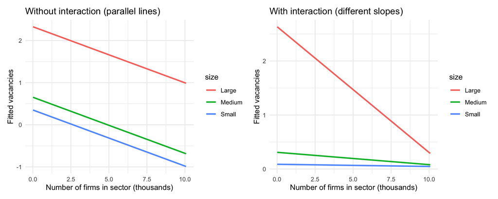

```r
df$fitted_par <- fitted(model_par)
df$fitted_int <- fitted(model_slopes)

## Use distinct n_firms values per size group for clean lines
plot_data <- aggregate(cbind(fitted_par, fitted_int) ~ n_firms + size, data = df, FUN = mean)

p1 <- ggplot(plot_data, aes(x = n_firms, y = fitted_par, color = size)) +
  geom_line(linewidth = 1) +
  labs(title = "Without interaction (parallel lines)",
       y = "Fitted vacancies", x = "Number of firms in sector (thousands)") +
  theme_minimal()

p2 <- ggplot(plot_data, aes(x = n_firms, y = fitted_int, color = size)) +
  geom_line(linewidth = 1) +
  labs(title = "With interaction (different slopes)",
       y = "Fitted vacancies", x = "Number of firms in sector (thousands)") +
  theme_minimal()

library(patchwork)
p1 + p2
```

**Python**

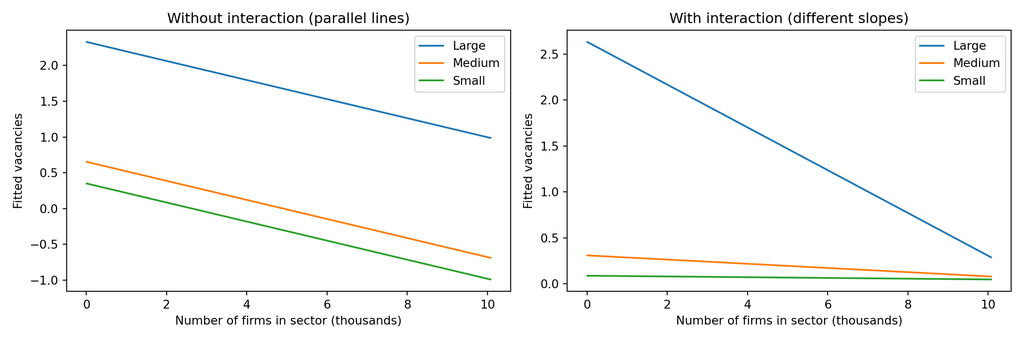

```python
df["fitted_par"] = model_par.fittedvalues
df["fitted_int"] = model_slopes.fittedvalues

plot_data = df.groupby(["n_firms", "size"])[["fitted_par", "fitted_int"]].mean().reset_index()

fig, axes = plt.subplots(1, 2, figsize=(12, 4))
for name, grp in plot_data.groupby("size"):
    axes[0].plot(grp["n_firms"], grp["fitted_par"], label=name)
    axes[1].plot(grp["n_firms"], grp["fitted_int"], label=name)
axes[0].set_title("Without interaction (parallel lines)")
axes[1].set_title("With interaction (different slopes)")
for ax in axes:
    ax.set_xlabel("Number of firms in sector (thousands)")
    ax.set_ylabel("Fitted vacancies")
    ax.legend()
plt.tight_layout()
plt.show()
```

## 4 Centering continuous variables

### 4.1 Why center?

In a model with interaction `vacancies ~ size * n_firms`, the “main effect” of `size` is the effect **when `n_firms = 0`**. But `n_firms = 0` is outside the observed range (there are no sectors with zero firms), so this main effect is an extrapolation with no practical meaning.

**Grand-mean centering** replaces `n_firms` with `n_firms - mean(n_firms)`. Now the main effect of `size` is the effect **at the average sector size**, which is much more interpretable.

### 4.2 Grand-mean centering

**R**

```r
df$n_firms_c <- df$n_firms - mean(df$n_firms)

model_cent <- lm(vacancies ~ size * n_firms_c, data = df)
summary(model_cent)
```

```
Call:
lm(formula = vacancies ~ size * n_firms_c, data = df)

Residuals:
   Min     1Q Median     3Q    Max
 -2.63  -2.08  -0.29  -0.08 889.37

Coefficients:
                     Estimate Std. Error t value Pr(>|t|)
(Intercept)           1.97117    0.05847  33.713  < 2e-16 ***
sizeMedium           -1.72706    0.09593 -18.002  < 2e-16 ***
sizeSmall            -1.89492    0.10639 -17.811  < 2e-16 ***
n_firms_c            -0.23297    0.01628 -14.311  < 2e-16 ***
sizeMedium:n_firms_c  0.21014    0.02643   7.950 1.91e-15 ***
sizeSmall:n_firms_c   0.22894    0.03637   6.295 3.10e-10 ***
---
Signif. codes:  0 '***' 0.001 '**' 0.01 '*' 0.05 '.' 0.1 ' ' 1

Residual standard error: 9.737 on 57474 degrees of freedom
Multiple R-squared:  0.01157,   Adjusted R-squared:  0.01148
F-statistic: 134.6 on 5 and 57474 DF,  p-value: < 2.2e-16
```

**Python**

```python
df["n_firms_c"] = df["n_firms"] - df["n_firms"].mean()

model_cent = smf.ols("vacancies ~ size * n_firms_c", data = df).fit()
print(model_cent.summary())
```

```
                            OLS Regression Results
==============================================================================
Dep. Variable:              vacancies   R-squared:                       0.012
Model:                            OLS   Adj. R-squared:                  0.011
Method:                 Least Squares   F-statistic:                     134.6
Date:                Sun, 26 Apr 2026   Prob (F-statistic):          2.64e-142
Time:                        12:37:31   Log-Likelihood:            -2.1238e+05
No. Observations:               57480   AIC:                         4.248e+05
Df Residuals:                   57474   BIC:                         4.248e+05
Df Model:                           5
Covariance Type:            nonrobust
============================================================================================
                               coef    std err          t      P>|t|      [0.025      0.975]
--------------------------------------------------------------------------------------------
Intercept                    1.9712      0.058     33.713      0.000       1.857       2.086
size[T.Medium]              -1.7271      0.096    -18.002      0.000      -1.915      -1.539
size[T.Small]               -1.8949      0.106    -17.811      0.000      -2.103      -1.686
n_firms_c                   -0.2330      0.016    -14.311      0.000      -0.265      -0.201
size[T.Medium]:n_firms_c     0.2101      0.026      7.950      0.000       0.158       0.262
size[T.Small]:n_firms_c      0.2289      0.036      6.295      0.000       0.158       0.300
==============================================================================
Omnibus:                   169371.542   Durbin-Watson:                   1.937
Prob(Omnibus):                  0.000   Jarque-Bera (JB):      15929746088.096
Skew:                          41.793   Prob(JB):                         0.00
Kurtosis:                    2580.647   Cond. No.                         11.4
==============================================================================

Notes:
[1] Standard Errors assume that the covariance matrix of the errors is correctly specified.
```

**Julia**

```julia
df.n_firms_c = df.n_firms .- mean(df.n_firms)
```

```
57480-element Vector{Float64}:
  0.4900108211551837
  0.4900108211551837
  0.4900108211551837
  0.4900108211551837
  0.4900108211551837
 -1.7159891788448165
 -1.7159891788448165
 -1.7159891788448165
 -1.7159891788448165
 -1.7159891788448165
  ⋮
  7.223010821155183
  7.223010821155183
 -1.7159891788448165
 -1.9249891788448164
  7.223010821155183
 -2.2359891788448163
 -2.2889891788448162
 -2.2889891788448162
 -2.4599891788448165
```

```julia
model_cent = lm(@formula(vacancies ~ size * n_firms_c), df)
```

```
StatsModels.TableRegressionModel{LinearModel{GLM.LmResp{Vector{Float64}}, GLM.DensePredChol{Float64, CholeskyPivoted{Float64, Matrix{Float64}, Vector{Int64}}}}, Matrix{Float64}}

vacancies ~ 1 + size + n_firms_c + size & n_firms_c

Coefficients:
───────────────────────────────────────────────────────────────────────────────────────
                              Coef.  Std. Error       t  Pr(>|t|)  Lower 95%  Upper 95%
───────────────────────────────────────────────────────────────────────────────────────
(Intercept)                1.97117    0.058469    33.71    <1e-99   1.85657    2.08577
size: Medium              -1.72706    0.0959343  -18.00    <1e-71  -1.91509   -1.53902
size: Small               -1.89492    0.106392   -17.81    <1e-70  -2.10345   -1.68639
n_firms_c                 -0.232966   0.0162785  -14.31    <1e-45  -0.264872  -0.20106
size: Medium & n_firms_c   0.210139   0.026434     7.95    <1e-14   0.158328   0.26195
size: Small & n_firms_c    0.228941   0.0363706    6.29    <1e-09   0.157654   0.300227
───────────────────────────────────────────────────────────────────────────────────────
```

### 4.3 What changes and what stays the same?

**R**

```r
## R-squared: identical
cat("R² (uncentered):", summary(model_slopes)$r.squared, "\n")
```

```
R² (uncentered): 0.01157001
```

```r
cat("R² (centered):  ", summary(model_cent)$r.squared, "\n")
```

```
R² (centered):   0.01157001
```

```r
## Interaction coefficients: identical
cat("\nInteraction coefs (uncentered):\n")
```

```
Interaction coefs (uncentered):
```

```r
print(coef(model_slopes)[5:6])
```

```
sizeMedium:n_firms  sizeSmall:n_firms
         0.2101388          0.2289407
```

```r
cat("Interaction coefs (centered):\n")
```

```
Interaction coefs (centered):
```

```r
print(coef(model_cent)[5:6])
```

```
sizeMedium:n_firms_c  sizeSmall:n_firms_c
           0.2101388            0.2289407
```

```r
## Main-effect coefficients: different
cat("\nMain effects (uncentered):\n")
```

```
Main effects (uncentered):
```

```r
print(coef(model_slopes)[1:3])
```

```
(Intercept)  sizeMedium   sizeSmall
   2.634652   -2.325529   -2.546940
```

```r
cat("Main effects (centered):\n")
```

```
Main effects (centered):
```

```r
print(coef(model_cent)[1:3])
```

```
(Intercept)  sizeMedium   sizeSmall
   1.971168   -1.727056   -1.894919
```

```r
## Fitted values: identical
cat("\nFitted values identical?", all.equal(fitted(model_slopes), fitted(model_cent)), "\n")
```

```
Fitted values identical? TRUE
```

**Python**

```python
## R-squared: identical
print(f"R² (uncentered): {model_slopes.rsquared:.6f}")
```

```
R² (uncentered): 0.011570
```

```python
print(f"R² (centered):   {model_cent.rsquared:.6f}")
```

```
R² (centered):   0.011570
```

```python
## Interaction coefficients: identical
print(f"\nInteraction coefs (uncentered):")
```

```
Interaction coefs (uncentered):
```

```python
print(model_slopes.params.filter(like=":"))
```

```
size[T.Medium]:n_firms    0.210139
size[T.Small]:n_firms     0.228941
dtype: float64
```

```python
print(f"Interaction coefs (centered):")
```

```
Interaction coefs (centered):
```

```python
print(model_cent.params.filter(like=":"))
```

```
size[T.Medium]:n_firms_c    0.210139
size[T.Small]:n_firms_c     0.228941
dtype: float64
```

```python
## Main-effect coefficients: different
print(f"\nMain effects (uncentered):")
```

```
Main effects (uncentered):
```

```python
print(model_slopes.params.iloc[:3])
```

```
Intercept         2.634652
size[T.Medium]   -2.325529
size[T.Small]    -2.546940
dtype: float64
```

```python
print(f"Main effects (centered):")
```

```
Main effects (centered):
```

```python
print(model_cent.params.iloc[:3])
```

```
Intercept         1.971168
size[T.Medium]   -1.727056
size[T.Small]    -1.894919
dtype: float64
```

**Julia**

```julia
## R-squared: identical
println("R² (uncentered): ", r2(model_slopes))
```

```
R² (uncentered): 0.011570012313749212
```

```julia
println("R² (centered):   ", r2(model_cent))
```

```
R² (centered):   0.011570012313749212
```

```julia
## Interaction coefficients: identical
println("\nInteraction coefs (uncentered): ", coef(model_slopes)[5:6])
```

```
Interaction coefs (uncentered): [0.21013884309311257, 0.22894067132381424]
```

```julia
println("Interaction coefs (centered):   ", coef(model_cent)[5:6])
```

```
Interaction coefs (centered):   [0.21013884309311356, 0.22894067132381524]
```

```julia
## Main-effect coefficients: different
println("\nMain effects (uncentered): ", coef(model_slopes)[1:3])
```

```
Main effects (uncentered): [2.6346516670851208, -2.3255286877484496, -2.5469396984041204]
```

```julia
println("Main effects (centered):   ", coef(model_cent)[1:3])
```

```
Main effects (centered):   [1.9711677789812498, -1.727055536564297, -1.8949191438764308]
```

### 4.4 Standardisation (z-score)

Standardising (`z-score`) additionally rescales to standard deviation units, so coefficients become comparable across variables with different scales.

**R**

```r
df$n_firms_s <- as.numeric(scale(df$n_firms))

model_std <- lm(vacancies ~ size * n_firms_s, data = df)
summary(model_std)
```

```
Call:
lm(formula = vacancies ~ size * n_firms_s, data = df)

Residuals:
   Min     1Q Median     3Q    Max
 -2.63  -2.08  -0.29  -0.08 889.37

Coefficients:
                     Estimate Std. Error t value Pr(>|t|)
(Intercept)           1.97117    0.05847  33.713  < 2e-16 ***
sizeMedium           -1.72706    0.09593 -18.002  < 2e-16 ***
sizeSmall            -1.89492    0.10639 -17.811  < 2e-16 ***
n_firms_s            -0.79967    0.05588 -14.311  < 2e-16 ***
sizeMedium:n_firms_s  0.72132    0.09074   7.950 1.91e-15 ***
sizeSmall:n_firms_s   0.78586    0.12484   6.295 3.10e-10 ***
---
Signif. codes:  0 '***' 0.001 '**' 0.01 '*' 0.05 '.' 0.1 ' ' 1

Residual standard error: 9.737 on 57474 degrees of freedom
Multiple R-squared:  0.01157,   Adjusted R-squared:  0.01148
F-statistic: 134.6 on 5 and 57474 DF,  p-value: < 2.2e-16
```

**Python**

```python
df["n_firms_s"] = (df["n_firms"] - df["n_firms"].mean()) / df["n_firms"].std()

model_std = smf.ols("vacancies ~ size * n_firms_s", data = df).fit()
print(model_std.summary())
```

```
                            OLS Regression Results
==============================================================================
Dep. Variable:              vacancies   R-squared:                       0.012
Model:                            OLS   Adj. R-squared:                  0.011
Method:                 Least Squares   F-statistic:                     134.6
Date:                Sun, 26 Apr 2026   Prob (F-statistic):          2.64e-142
Time:                        12:37:32   Log-Likelihood:            -2.1238e+05
No. Observations:               57480   AIC:                         4.248e+05
Df Residuals:                   57474   BIC:                         4.248e+05
Df Model:                           5
Covariance Type:            nonrobust
============================================================================================
                               coef    std err          t      P>|t|      [0.025      0.975]
--------------------------------------------------------------------------------------------
Intercept                    1.9712      0.058     33.713      0.000       1.857       2.086
size[T.Medium]              -1.7271      0.096    -18.002      0.000      -1.915      -1.539
size[T.Small]               -1.8949      0.106    -17.811      0.000      -2.103      -1.686
n_firms_s                   -0.7997      0.056    -14.311      0.000      -0.909      -0.690
size[T.Medium]:n_firms_s     0.7213      0.091      7.950      0.000       0.543       0.899
size[T.Small]:n_firms_s      0.7859      0.125      6.295      0.000       0.541       1.031
==============================================================================
Omnibus:                   169371.542   Durbin-Watson:                   1.937
Prob(Omnibus):                  0.000   Jarque-Bera (JB):      15929746088.096
Skew:                          41.793   Prob(JB):                         0.00
Kurtosis:                    2580.647   Cond. No.                         3.63
==============================================================================

Notes:
[1] Standard Errors assume that the covariance matrix of the errors is correctly specified.
```

**Julia**

```julia
df.n_firms_s = (df.n_firms .- mean(df.n_firms)) ./ std(df.n_firms)
```

```
57480-element Vector{Float64}:
  0.14275288789231136
  0.14275288789231136
  0.14275288789231136
  0.14275288789231136
  0.14275288789231136
 -0.49991224743682805
 -0.49991224743682805
 -0.49991224743682805
 -0.49991224743682805
 -0.49991224743682805
  ⋮
  2.104250782802146
  2.104250782802146
 -0.49991224743682805
 -0.5607993794784374
  2.104250782802146
 -0.651401762564277
 -0.6668420400676516
 -0.6668420400676516
 -0.716658784465332
```

```julia
model_std = lm(@formula(vacancies ~ size * n_firms_s), df)
```

```
StatsModels.TableRegressionModel{LinearModel{GLM.LmResp{Vector{Float64}}, GLM.DensePredChol{Float64, CholeskyPivoted{Float64, Matrix{Float64}, Vector{Int64}}}}, Matrix{Float64}}

vacancies ~ 1 + size + n_firms_s + size & n_firms_s

Coefficients:
───────────────────────────────────────────────────────────────────────────────────────
                              Coef.  Std. Error       t  Pr(>|t|)  Lower 95%  Upper 95%
───────────────────────────────────────────────────────────────────────────────────────
(Intercept)                1.97117    0.058469    33.71    <1e-99   1.85657    2.08577
size: Medium              -1.72706    0.0959343  -18.00    <1e-71  -1.91509   -1.53902
size: Small               -1.89492    0.106392   -17.81    <1e-70  -2.10345   -1.68639
n_firms_s                 -0.799674   0.0558773  -14.31    <1e-45  -0.909194  -0.690154
size: Medium & n_firms_s   0.721319   0.0907369    7.95    <1e-14   0.543474   0.899163
size: Small & n_firms_s    0.785857   0.124845     6.29    <1e-09   0.541161   1.03055
───────────────────────────────────────────────────────────────────────────────────────
```

## 5 Gelman’s approach: scaling by two standard deviations

### 5.1 The problem with standard standardisation

When comparing continuous and binary predictors in the same model, dividing the continuous input by 1 SD does not make coefficients directly comparable:

- A binary (0/1) variable like `public` has a natural 1-unit change (from 0 to 1), representing its full range.
- For a continuous variable, a 1-SD change is only a moderate shift – roughly covering 68% of the distribution.

Gelman (2008) proposes a simple fix: **divide continuous inputs by 2 SD** instead of 1 SD. Then a 1-unit change in the rescaled continuous variable corresponds to moving from 1 SD below to 1 SD above the mean – a “typical” swing that is more comparable in magnitude to the 0-to-1 swing of a binary predictor.

### 5.2 Centering binary variables by their means

Gelman also recommends **centering binary inputs by their means**. Instead of leaving `public` as 0/1 with the intercept representing the `public = 0` group:

- Replace `public` with `public - mean(public)`
- The intercept now represents the expected value at the “average” mix of public/private firms, not just at the reference level

This is especially useful in models with interactions, where the “main effect” of a categorical variable is conditional on the other variable being at its reference level.

### 5.3 Implementation

**R**

```r
## Gelman scaling: continuous by 2*SD
df$n_firms_g <- (df$n_firms - mean(df$n_firms)) / (2 * sd(df$n_firms))

## Center binary by its mean
df$public_num <- as.numeric(df$public == "1")
df$public_c <- df$public_num - mean(df$public_num)

## Model with Gelman-scaled inputs
model_gelman <- lm(vacancies ~ size + n_firms_g + public_c, data = df)
summary(model_gelman)
```

```
Call:
lm(formula = vacancies ~ size + n_firms_g + public_c, data = df)

Residuals:
   Min     1Q Median     3Q    Max
 -2.39  -2.00  -0.57  -0.10 889.90

Coefficients:
            Estimate Std. Error t value Pr(>|t|)
(Intercept)  1.96738    0.05879  33.467  < 2e-16 ***
sizeMedium  -1.69803    0.09609 -17.672  < 2e-16 ***
sizeSmall   -2.02823    0.10526 -19.270  < 2e-16 ***
n_firms_g   -0.77898    0.09411  -8.277  < 2e-16 ***
public_c    -0.29187    0.09972  -2.927  0.00343 **
---
Signif. codes:  0 '***' 0.001 '**' 0.01 '*' 0.05 '.' 0.1 ' ' 1

Residual standard error: 9.744 on 57475 degrees of freedom
Multiple R-squared:  0.01032,   Adjusted R-squared:  0.01025
F-statistic: 149.8 on 4 and 57475 DF,  p-value: < 2.2e-16
```

**Python**

```python
## Gelman scaling
df["n_firms_g"] = (df["n_firms"] - df["n_firms"].mean()) / (2 * df["n_firms"].std())

## Center binary by its mean
df["public_num"] = (df["public"] == "1").astype(float)
df["public_c"] = df["public_num"] - df["public_num"].mean()

model_gelman = smf.ols("vacancies ~ size + n_firms_g + public_c", data=df).fit()
print(model_gelman.summary())
```

```
                            OLS Regression Results
==============================================================================
Dep. Variable:              vacancies   R-squared:                       0.010
Model:                            OLS   Adj. R-squared:                  0.010
Method:                 Least Squares   F-statistic:                     149.8
Date:                Sun, 26 Apr 2026   Prob (F-statistic):          1.10e-127
Time:                        12:37:32   Log-Likelihood:            -2.1242e+05
No. Observations:               57480   AIC:                         4.248e+05
Df Residuals:                   57475   BIC:                         4.249e+05
Df Model:                           4
Covariance Type:            nonrobust
==================================================================================
                     coef    std err          t      P>|t|      [0.025      0.975]
----------------------------------------------------------------------------------
Intercept          1.9674      0.059     33.467      0.000       1.852       2.083
size[T.Medium]    -1.6980      0.096    -17.672      0.000      -1.886      -1.510
size[T.Small]     -2.0282      0.105    -19.270      0.000      -2.235      -1.822
n_firms_g         -0.7790      0.094     -8.277      0.000      -0.963      -0.595
public_c          -0.2919      0.100     -2.927      0.003      -0.487      -0.096
==============================================================================
Omnibus:                   169327.726   Durbin-Watson:                   1.936
Prob(Omnibus):                  0.000   Jarque-Bera (JB):      15896734351.470
Skew:                          41.763   Prob(JB):                         0.00
Kurtosis:                    2577.974   Cond. No.                         3.42
==============================================================================

Notes:
[1] Standard Errors assume that the covariance matrix of the errors is correctly specified.
```

**Julia**

```julia
df.n_firms_g = (df.n_firms .- mean(df.n_firms)) ./ (2 * std(df.n_firms))
```

```
57480-element Vector{Float64}:
  0.07137644394615568
  0.07137644394615568
  0.07137644394615568
  0.07137644394615568
  0.07137644394615568
 -0.24995612371841402
 -0.24995612371841402
 -0.24995612371841402
 -0.24995612371841402
 -0.24995612371841402
  ⋮
  1.052125391401073
  1.052125391401073
 -0.24995612371841402
 -0.2803996897392187
  1.052125391401073
 -0.3257008812821385
 -0.3334210200338258
 -0.3334210200338258
 -0.358329392232666
```

```julia
df.public_num = Float64.(df.public .== "1")
```

```
57480-element Vector{Float64}:
 1.0
 1.0
 1.0
 1.0
 1.0
 1.0
 1.0
 1.0
 1.0
 1.0
 ⋮
 1.0
 1.0
 1.0
 0.0
 1.0
 1.0
 0.0
 0.0
 0.0
```

```julia
df.public_c = df.public_num .- mean(df.public_num)
```

```
57480-element Vector{Float64}:
  0.6476339596381351
  0.6476339596381351
  0.6476339596381351
  0.6476339596381351
  0.6476339596381351
  0.6476339596381351
  0.6476339596381351
  0.6476339596381351
  0.6476339596381351
  0.6476339596381351
  ⋮
  0.6476339596381351
  0.6476339596381351
  0.6476339596381351
 -0.352366040361865
  0.6476339596381351
  0.6476339596381351
 -0.352366040361865
 -0.352366040361865
 -0.352366040361865
```

```julia
model_gelman = lm(@formula(vacancies ~ size + n_firms_g + public_c), df)
```

```
StatsModels.TableRegressionModel{LinearModel{GLM.LmResp{Vector{Float64}}, GLM.DensePredChol{Float64, CholeskyPivoted{Float64, Matrix{Float64}, Vector{Int64}}}}, Matrix{Float64}}

vacancies ~ 1 + size + n_firms_g + public_c

Coefficients:
────────────────────────────────────────────────────────────────────────────
                  Coef.  Std. Error       t  Pr(>|t|)  Lower 95%   Upper 95%
────────────────────────────────────────────────────────────────────────────
(Intercept)    1.96738    0.0587864   33.47    <1e-99   1.85216    2.0826
size: Medium  -1.69803    0.0960861  -17.67    <1e-68  -1.88636   -1.5097
size: Small   -2.02823    0.105255   -19.27    <1e-81  -2.23453   -1.82193
n_firms_g     -0.778982   0.0941142   -8.28    <1e-15  -0.963447  -0.594518
public_c      -0.291871   0.0997236   -2.93    0.0034  -0.487329  -0.0964118
────────────────────────────────────────────────────────────────────────────
```

### 5.4 Comparison: coefficient magnitudes

Compare the same model under three scaling approaches to see how coefficient comparability changes.

**R**

```r
## Original (no scaling)
model_orig <- lm(vacancies ~ size + n_firms + public_num, data = df)

## Standard z-score (1 SD)
model_1sd <- lm(vacancies ~ size + n_firms_s + public_num, data = df)

## Gelman (2 SD for continuous, mean-centered binary)
model_2sd <- lm(vacancies ~ size + n_firms_g + public_c, data = df)

comparison <- data.frame(
  original = coef(model_orig),
  z_score_1sd = coef(model_1sd),
  gelman_2sd = coef(model_2sd)
)
round(comparison, 4)
```

|  | original | z_score_1sd | gelman_2sd |
| --- | --- | --- | --- |
| (Intercept) | 2.3934 | 2.0702 | 1.9674 |
| sizeMedium | -1.6980 | -1.6980 | -1.6980 |
| sizeSmall | -2.0282 | -2.0282 | -2.0282 |
| n_firms | -0.1135 | -0.3895 | -0.7790 |
| public_num | -0.2919 | -0.2919 | -0.2919 |

Note how the Gelman-scaled coefficient for `n_firms_g` and `public_c` are now on a more comparable scale: both represent the effect of a “typical” change in the predictor.

**Python**

```python
model_orig = smf.ols("vacancies ~ size + n_firms + public_num", data=df).fit()
model_1sd = smf.ols("vacancies ~ size + n_firms_s + public_num", data=df).fit()
model_2sd = smf.ols("vacancies ~ size + n_firms_g + public_c", data=df).fit()

comparison = pd.DataFrame({
    "original": model_orig.params,
    "z_score_1sd": model_1sd.params,
    "gelman_2sd": model_2sd.params
})
print(comparison.round(4))
```

```
                original  z_score_1sd  gelman_2sd
Intercept         2.3934       2.0702      1.9674
n_firms          -0.1135          NaN         NaN
n_firms_g            NaN          NaN     -0.7790
n_firms_s            NaN      -0.3895         NaN
public_c             NaN          NaN     -0.2919
public_num       -0.2919      -0.2919         NaN
size[T.Medium]   -1.6980      -1.6980     -1.6980
size[T.Small]    -2.0282      -2.0282     -2.0282
```

**Julia**

```julia
model_orig = lm(@formula(vacancies ~ size + n_firms + public_num), df)
```

```
StatsModels.TableRegressionModel{LinearModel{GLM.LmResp{Vector{Float64}}, GLM.DensePredChol{Float64, CholeskyPivoted{Float64, Matrix{Float64}, Vector{Int64}}}}, Matrix{Float64}}

vacancies ~ 1 + size + n_firms + public_num

Coefficients:
────────────────────────────────────────────────────────────────────────────
                  Coef.  Std. Error       t  Pr(>|t|)  Lower 95%   Upper 95%
────────────────────────────────────────────────────────────────────────────
(Intercept)    2.39339    0.0724213   33.05    <1e-99   2.25144    2.53533
size: Medium  -1.69803    0.0960861  -17.67    <1e-68  -1.88636   -1.5097
size: Small   -2.02823    0.105255   -19.27    <1e-81  -2.23453   -1.82193
n_firms       -0.113469   0.013709    -8.28    <1e-15  -0.140339  -0.0865993
public_num    -0.291871   0.0997236   -2.93    0.0034  -0.487329  -0.0964118
────────────────────────────────────────────────────────────────────────────
```

```julia
model_1sd = lm(@formula(vacancies ~ size + n_firms_s + public_num), df)
```

```
StatsModels.TableRegressionModel{LinearModel{GLM.LmResp{Vector{Float64}}, GLM.DensePredChol{Float64, CholeskyPivoted{Float64, Matrix{Float64}, Vector{Int64}}}}, Matrix{Float64}}

vacancies ~ 1 + size + n_firms_s + public_num

Coefficients:
────────────────────────────────────────────────────────────────────────────
                  Coef.  Std. Error       t  Pr(>|t|)  Lower 95%   Upper 95%
────────────────────────────────────────────────────────────────────────────
(Intercept)    2.07023    0.071618    28.91    <1e-99   1.92986    2.2106
size: Medium  -1.69803    0.0960861  -17.67    <1e-68  -1.88636   -1.5097
size: Small   -2.02823    0.105255   -19.27    <1e-81  -2.23453   -1.82193
n_firms_s     -0.389491   0.0470571   -8.28    <1e-15  -0.481723  -0.297259
public_num    -0.291871   0.0997236   -2.93    0.0034  -0.487329  -0.0964118
────────────────────────────────────────────────────────────────────────────
```

```julia
model_2sd = lm(@formula(vacancies ~ size + n_firms_g + public_c), df)
```

```
StatsModels.TableRegressionModel{LinearModel{GLM.LmResp{Vector{Float64}}, GLM.DensePredChol{Float64, CholeskyPivoted{Float64, Matrix{Float64}, Vector{Int64}}}}, Matrix{Float64}}

vacancies ~ 1 + size + n_firms_g + public_c

Coefficients:
────────────────────────────────────────────────────────────────────────────
                  Coef.  Std. Error       t  Pr(>|t|)  Lower 95%   Upper 95%
────────────────────────────────────────────────────────────────────────────
(Intercept)    1.96738    0.0587864   33.47    <1e-99   1.85216    2.0826
size: Medium  -1.69803    0.0960861  -17.67    <1e-68  -1.88636   -1.5097
size: Small   -2.02823    0.105255   -19.27    <1e-81  -2.23453   -1.82193
n_firms_g     -0.778982   0.0941142   -8.28    <1e-15  -0.963447  -0.594518
public_c      -0.291871   0.0997236   -2.93    0.0034  -0.487329  -0.0964118
────────────────────────────────────────────────────────────────────────────
```

```julia
println("Original:    ", round.(coef(model_orig), digits=4))
```

```
Original:    [2.3934, -1.698, -2.0282, -0.1135, -0.2919]
```

```julia
println("Z-score 1SD: ", round.(coef(model_1sd), digits=4))
```

```
Z-score 1SD: [2.0702, -1.698, -2.0282, -0.3895, -0.2919]
```

```julia
println("Gelman 2SD:  ", round.(coef(model_2sd), digits=4))
```

```
Gelman 2SD:  [1.9674, -1.698, -2.0282, -0.779, -0.2919]
```